# Laboratorium 16

## Parametry wejściowe:

### Earthquake:

Zakładamy średnio 3 trzęsienia ziemi rocznie. P(Earthquake) = 3 / 365 = 0.0082

- **P(True) =** 0.0082
- **P(False) =** 0.9918

### Alarm:

- **Burglary = True | Earthquake = False**:

Z zadania - Alarm działa w **95%** skuteczności. -> P(True) = 0.95.

- **Burglary = True | Earthquake = True**:

Można założyć że zadziała z nieco większym prawdopodobieństwem niż bez trzęsienia ziemi - **97%**. -> P(True) = 0.97.

- **Burglary = False | Earthquake = True**:

Z zadania - Alarm włącza się przy 1 na 5 trzęsień ziemi, **20%** szans. -> P(True) = 0.2

- **Burglary = False | Earthquake = False**:

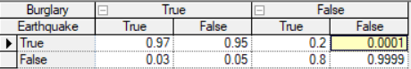

### Radio News:

Z zadania - nigdy nie zawiedli informując poprawnie w aktualnym stanie, lecz potrafią podać informację gdy nastąpi w innym stanie.

- **Earthquake = True:** P(True) = 1.
- **Earthquake = False:** P(True) = 0.02 (czasem się pomylą, ale nie aż tak często).

### Watson Call:

- **Alarm = True:** Watson jest troche głuchy, więc może nie usłyszeć: **P(True) = 0.95**.
- **Alarm = False:** Watson nie żartuje, jest poważny: **P(True) = 0**.

## Kilka przykładów użycia:

### Zdarzyło się włamanie ale nie ma trzęsienia ziemi.

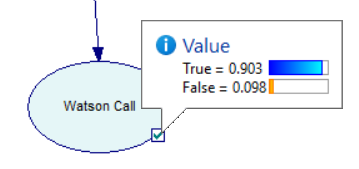

Watson raczej na pewno zadzwoni (chyba że ogłuchł zupełnie).

### Nie wiemy czy było włamanie, ale radio podało, że było trzęsienie ziemi.

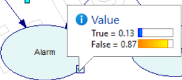

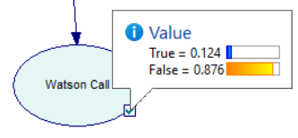

Watson raczej nie zadzwoni i alarm nie zawyje. Ale trzęsienie ziemi faktycznie się zdarzyło:

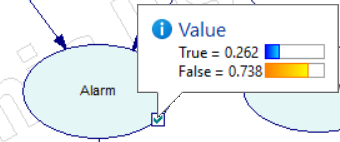

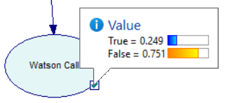

Okazało się, że w trakcie trzęsienia ziemi ktoś wykorzystał efekt paniki wśród ludzi i włamał się do Watsona. Wtedy pewność prawdopodobieństwo alarmu jest już praktycznie bliska pewności, a Watson już dawno wykręcił numer do Holmsa:

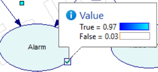

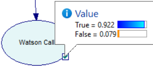

### Co jeśli Holmes bez żadnych przesłanek dostanie telefon od Watsona?

Przez to, że Watson jest śmiertelnie poważny i nigdy nie żartuje, sprawia że jego telefon USTAWIA Prawdopodobieństwo alarmu automatycznie na pewne.

[figure not shown]

To sprawia również, że prawdopodobieństwo włamania automatycznie też staje się prawie że pewne.